# Actividad LAB02 - Cross Validation

Jorge Arturo Huima Ruiz

2026-10-04

# 1 Introducción

Para esta actividad voy a partir de la práctica LAB02 de Cross Validation.

Voy a seguir trabajando con el dataset `Auto` y con el modelo lineal que relaciona el peso del coche (`weight`) con la potencia (`horsepower`).

La idea de la tarea es ampliar un poco lo que ya se hizo en la práctica. Por un lado, además de mirar errores como MAE o RMSE, voy a comparar también si la distribución de los valores predichos se parece a la de los valores reales.

Por otro lado, voy a probar distintos valores de K en la validación cruzada y repetir el proceso varias veces para ver cómo cambia el error y si hay más o menos variabilidad dependiendo del número de folds.

# 2 Preparación de los datos

Primero cargo las librerías y el dataset que se utiliza en la práctica.

```r
library(ISLR)
library(caret)

data(Auto)

str(Auto)
```

```
## 'data.frame':    392 obs. of  9 variables:
##  $ mpg         : num  18 15 18 16 17 15 14 14 14 15 ...
##  $ cylinders   : num  8 8 8 8 8 8 8 8 8 8 ...
##  $ displacement: num  307 350 318 304 302 429 454 440 455 390 ...
##  $ horsepower  : num  130 165 150 150 140 198 220 215 225 190 ...
##  $ weight      : num  3504 3693 3436 3433 3449 ...
##  $ acceleration: num  12 11.5 11 12 10.5 10 9 8.5 10 8.5 ...
##  $ year        : num  70 70 70 70 70 70 70 70 70 70 ...
##  $ origin      : num  1 1 1 1 1 1 1 1 1 1 ...
##  $ name        : Factor w/ 304 levels "amc ambassador brougham",..: 49 36 231 14 161 141 54 223 241 2 ...
```

Como en la práctica original, convierto el peso de libras a kilogramos.

También cambio la variable `origin` para trabajar con los nombres de los grupos.

```r
Auto$weight <- Auto$weight * 0.453592

Auto$origin <- as.character(
  factor(
    Auto$origin,
    labels = c("American", "Japanese", "European")
  )
)

america <- Auto[Auto$origin == "American", ]
japan <- Auto[Auto$origin == "Japanese", ]
europe <- Auto[Auto$origin == "European", ]

nrow(america)
```

```
## [1] 245
```

```r
nrow(japan)
```

```
## [1] 68
```

```r
nrow(europe)
```

```
## [1] 79
```

# 3 Funciones de error

Uso las mismas funciones de error que aparecen en la práctica.

```r
mae <- function(obs, est) {
  mean(abs(obs - est))
}

rmse <- function(obs, est) {
  sqrt(mean((obs - est)^2))
}
```

# 4 Tarea 1.1

En la práctica anterior se utilizan medidas como MAE y RMSE.

Estas medidas sirven para ver cuánto se aleja cada predicción de su valor real.

En esta parte quiero añadir otra forma de comprobar el modelo, comparando no solamente cada valor por separado, sino también la forma general de la distribución de los datos observados y los predichos.

## 4.1 Modelo con los coches americanos

Primero creo el modelo utilizando los coches americanos.

```r
modelo_america <- lm(
  weight ~ horsepower,
  data = america
)

summary(modelo_america)
```

```
##
## Call:
## lm(formula = weight ~ horsepower, data = america)
##
## Residuals:
##     Min      1Q  Median      3Q     Max
## -933.21 -150.12   -7.56  135.51  502.21
##
## Coefficients:
##             Estimate Std. Error t value Pr(>|t|)
## (Intercept) 627.1749    39.6826   15.80   <2e-16 ***
## horsepower    7.5814     0.3161   23.98   <2e-16 ***
## ---
## Signif. codes:  0 '***' 0.001 '**' 0.01 '*' 0.05 '.' 0.1 ' ' 1
##
## Residual standard error: 197 on 243 degrees of freedom
## Multiple R-squared:  0.703,  Adjusted R-squared:  0.7018
## F-statistic: 575.2 on 1 and 243 DF,  p-value: < 2.2e-16
```

## 4.2 Predicción para los coches europeos

Uso el modelo anterior para estimar el peso de los coches europeos.

```r
pred_europe <- predict(
  modelo_america,
  newdata = europe
)
```

Calculo los errores.

```r
rmse_europe <- rmse(
  europe$weight,
  pred_europe
)

mae_europe <- mae(
  europe$weight,
  pred_europe
)

rmse_europe
```

```
## [1] 236.2701
```

```r
mae_europe
```

```
## [1] 225.0868
```

## 4.3 Predicción para los coches japoneses

Ahora hago lo mismo con los coches japoneses.

```r
pred_japan <- predict(
  modelo_america,
  newdata = japan
)
```

```r
rmse_japan <- rmse(
  japan$weight,
  pred_japan
)

mae_japan <- mae(
  japan$weight,
  pred_japan
)

rmse_japan
```

```
## [1] 221.2345
```

```r
mae_japan
```

```
## [1] 200.8175
```

# 5 Comparación de las distribuciones

Para ver si los valores predichos tienen una distribución parecida a los reales, primero hago una comparación gráfica.

## 5.1 Europa

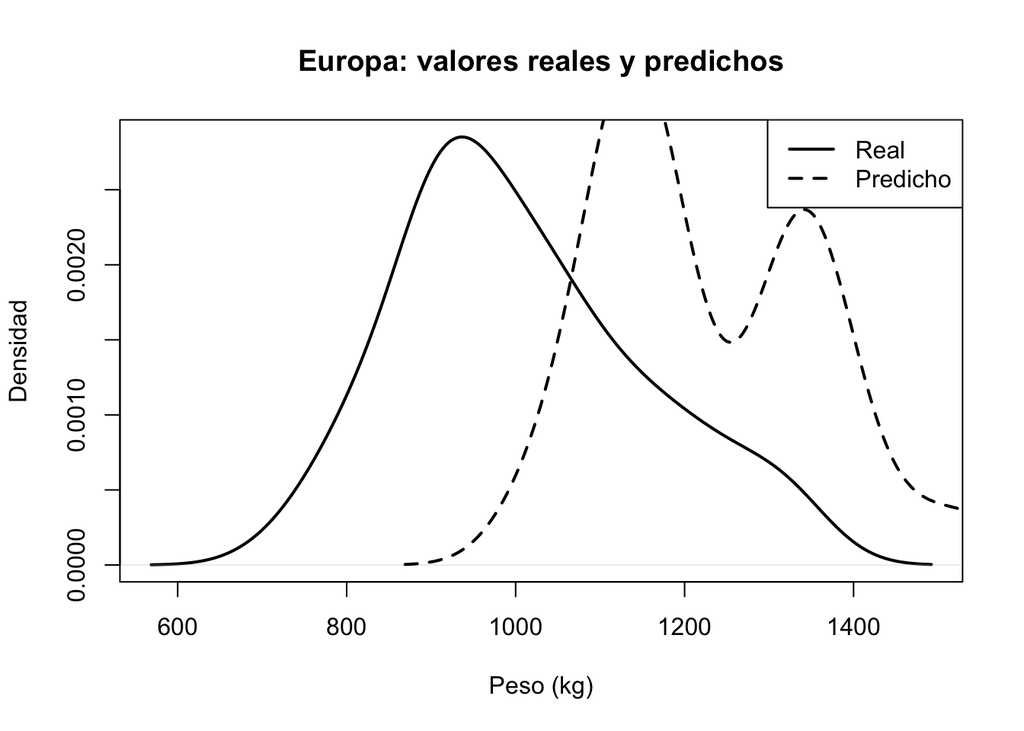

```r
plot(
  density(europe$weight),
  main = "Europa: valores reales y predichos",
  xlab = "Peso (kg)",
  ylab = "Densidad",
  lwd = 2
)

lines(
  density(pred_europe),
  lwd = 2,
  lty = 2
)

legend(
  "topright",
  legend = c("Real", "Predicho"),
  lty = c(1, 2),
  lwd = 2
)
```

## 5.2 Japón

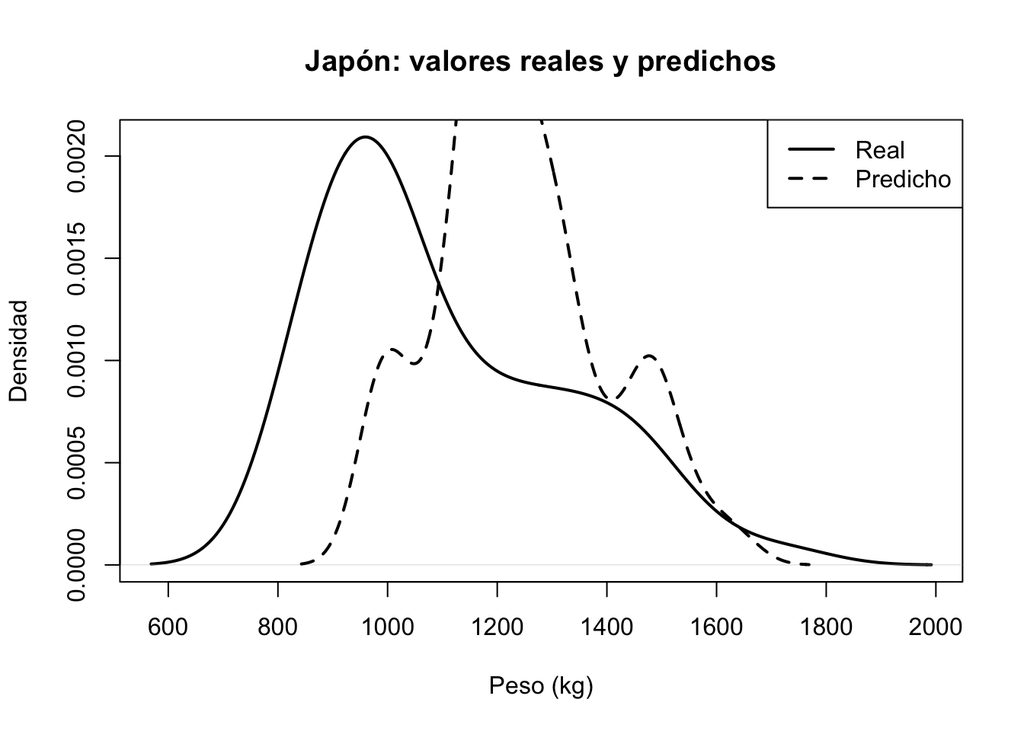

```r
plot(
  density(japan$weight),
  main = "Japón: valores reales y predichos",
  xlab = "Peso (kg)",
  ylab = "Densidad",
  lwd = 2
)

lines(
  density(pred_japan),
  lwd = 2,
  lty = 2
)

legend(
  "topright",
  legend = c("Real", "Predicho"),
  lty = c(1, 2),
  lwd = 2
)
```

Además de los gráficos, también voy a utilizar el test de Kolmogorov-Smirnov para comparar las distribuciones.

```r
ks_europe <- ks.test(
  europe$weight,
  pred_europe
)

ks_japan <- ks.test(
  japan$weight,
  pred_japan
)

ks_europe
```

```
##
##  Exact two-sample Kolmogorov-Smirnov test
##
## data:  europe$weight and pred_europe
## D = 0.65823, p-value < 2.2e-16
## alternative hypothesis: two-sided
```

```r
ks_japan
```

```
##
##  Exact two-sample Kolmogorov-Smirnov test
##
## data:  japan$weight and pred_japan
## D = 0.47059, p-value = 2.551e-07
## alternative hypothesis: two-sided
```

Para resumir los resultados, los junto en una tabla.

```r
resultados_1_1 <- data.frame(
  Conjunto = c("Europa", "Japón"),

  RMSE = c(
    rmse_europe,
    rmse_japan
  ),

  MAE = c(
    mae_europe,
    mae_japan
  ),

  KS_D = c(
    unname(ks_europe$statistic),
    unname(ks_japan$statistic)
  ),

  KS_p_value = c(
    ks_europe$p.value,
    ks_japan$p.value
  )
)

resultados_1_1
```

```
##   Conjunto     RMSE      MAE      KS_D   KS_p_value
## 1   Europa 236.2701 225.0868 0.6582278 7.476184e-17
## 2    Japón 221.2345 200.8175 0.4705882 2.550672e-07
```

## 5.3 Comentario de la Tarea 1.1

Viendo los resultados, el modelo entrenado con los coches americanos se comporta algo mejor al predecir los coches japoneses que los europeos. Para Europa he obtenido un RMSE de 236.27 y un MAE de 225.09, mientras que para Japón los valores son algo menores, con un RMSE de 221.23 y un MAE de 200.82.  
Al comparar las distribuciones con el test de Kolmogorov-Smirnov, los p-values son muy inferiores a 0.05 en los dos casos. Por tanto, hay evidencia de que las distribuciones de los valores predichos y observados son diferentes tanto para Europa como para Japón.  
También se observa que el estadístico KS es mayor para Europa (0.658) que para Japón (0.471), por lo que las predicciones realizadas sobre los coches japoneses se aproximan algo más a la distribución real.  
En este caso, las dos formas de evaluación llevan a una conclusión parecida: el modelo no generaliza especialmente bien cuando se aplica a coches de otros orígenes, aunque el resultado es algo mejor para los coches japoneses. MAE y RMSE indican el error de cada predicción, mientras que el test KS aporta información sobre el comportamiento global de la distribución. Por eso ambas medidas se complementan.

# 6 Tarea 1.2

En esta parte voy a probar distintos valores de K para la validación cruzada.

Voy a utilizar:

- K = 2
- K = 5
- K = 10

La idea es repetir cada validación varias veces porque el resultado puede cambiar dependiendo de cómo se dividan los datos en los folds.

## 6.1 Función para hacer Cross Validation

Creo una función que hace la validación k-fold y devuelve el RMSE total.

```r
cv_rmse <- function(data, k, seed) {

  set.seed(seed)

  folds <- createFolds(
    data$weight,
    k = k,
    list = TRUE,
    returnTrain = FALSE
  )

  observados <- c()
  predichos <- c()

  for (i in seq_along(folds)) {

    test_idx <- folds[[i]]

    train_data <- data[-test_idx, ]
    test_data <- data[test_idx, ]

    modelo <- lm(
      weight ~ horsepower,
      data = train_data
    )

    pred <- predict(
      modelo,
      newdata = test_data
    )

    observados <- c(
      observados,
      test_data$weight
    )

    predichos <- c(
      predichos,
      pred
    )
  }

  rmse(
    observados,
    predichos
  )
}
```

Primero hago una prueba simple con cada valor de K.

```r
cv_rmse(europe, 2, 1)
```

```
## [1] 71.87714
```

```r
cv_rmse(europe, 5, 1)
```

```
## [1] 72.40267
```

```r
cv_rmse(europe, 10, 1)
```

```
## [1] 73.57008
```

## 6.2 Repetir varias veces la validación

Voy a repetir el proceso 50 veces para cada valor de K.

Cada vez cambio la semilla para obtener una partición diferente.

```r
repeticiones <- 50

errores_k2 <- sapply(
  1:repeticiones,
  function(i) {
    cv_rmse(europe, 2, i)
  }
)

errores_k5 <- sapply(
  1:repeticiones,
  function(i) {
    cv_rmse(europe, 5, i)
  }
)

errores_k10 <- sapply(
  1:repeticiones,
  function(i) {
    cv_rmse(europe, 10, i)
  }
)
```

# 7 Resumen de resultados

Ahora calculo el error medio y la desviación estándar para cada K.

La desviación estándar me sirve para ver cuánto cambia el error entre una repetición y otra.

```r
resultados_1_2 <- data.frame(
  K = c(2, 5, 10),

  RMSE_medio = c(
    mean(errores_k2),
    mean(errores_k5),
    mean(errores_k10)
  ),

  Desviacion = c(
    sd(errores_k2),
    sd(errores_k5),
    sd(errores_k10)
  ),

  Minimo = c(
    min(errores_k2),
    min(errores_k5),
    min(errores_k10)
  ),

  Maximo = c(
    max(errores_k2),
    max(errores_k5),
    max(errores_k10)
  )
)

resultados_1_2
```

```
##    K RMSE_medio Desviacion   Minimo   Maximo
## 1  2   73.84021  2.1851657 71.87714 82.94869
## 2  5   73.14982  0.6146209 72.17319 74.48723
## 3 10   73.11476  0.4009933 72.29422 74.02419
```

## 7.1 Boxplot

Para verlo mejor hago un boxplot con los errores de las 50 repeticiones.

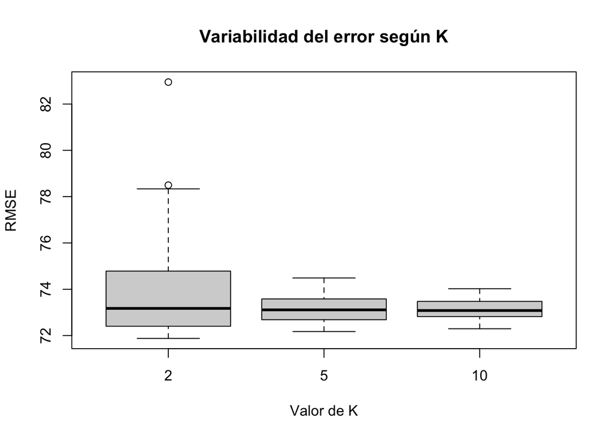

```r
errores <- data.frame(
  RMSE = c(
    errores_k2,
    errores_k5,
    errores_k10
  ),

  K = factor(
    rep(
      c(2, 5, 10),
      each = repeticiones
    )
  )
)

boxplot(
  RMSE ~ K,
  data = errores,
  xlab = "Valor de K",
  ylab = "RMSE",
  main = "Variabilidad del error según K"
)
```

## 7.2 Variación del error en las repeticiones

También represento el error de cada repetición para ver cómo va cambiando.

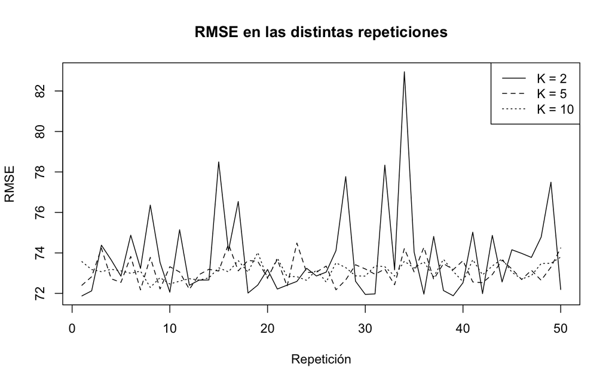

```r
plot(
  errores_k2,
  type = "l",
  ylim = range(
    c(
      errores_k2,
      errores_k5,
      errores_k10
    )
  ),
  xlab = "Repetición",
  ylab = "RMSE",
  main = "RMSE en las distintas repeticiones"
)

lines(
  errores_k5,
  lty = 2
)

lines(
  errores_k10,
  lty = 3
)

legend(
  "topright",
  legend = c(
    "K = 2",
    "K = 5",
    "K = 10"
  ),
  lty = c(
    1,
    2,
    3
  )
)
```